# Central Limit Theorem

## Inferential Statistics and Hypothesis Testing - Introduction

### Central Limit Theorem

```python
import numpy as np
import pandas as pd
import matplotlib.pyplot as plt
import seaborn as sns
```

```python
# Rolling a die for 100 time - with 6 faces
one_h = np.random.randint(1,7,100)
one_m = np.random.randint(1,7,1000000)
one_h
```

```
array([2, 4, 2, 6, 2, 3, 1, 1, 2, 2, 2, 3, 3, 6, 5, 5, 6, 4, 4, 4, 4, 2,
       5, 3, 1, 2, 3, 3, 4, 1, 4, 5, 4, 2, 3, 3, 1, 3, 6, 3, 5, 6, 2, 4,
       1, 2, 6, 6, 5, 1, 6, 2, 5, 1, 4, 4, 1, 4, 3, 1, 1, 2, 4, 1, 3, 1,
       6, 4, 3, 6, 2, 6, 5, 6, 4, 6, 3, 5, 5, 3, 3, 5, 3, 4, 1, 2, 1, 4,
       4, 5, 6, 5, 6, 3, 4, 2, 5, 1, 3, 2])
```

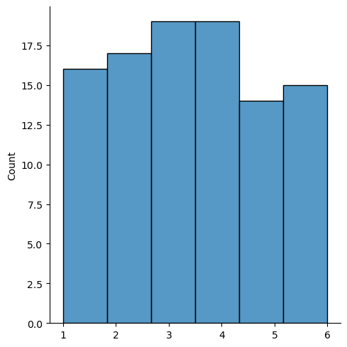

```python
#Creating a Histogram
sns.displot(x=one_h, bins=6)
```

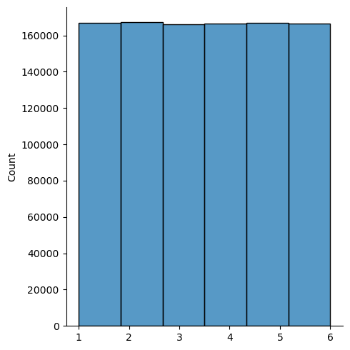

```python
sns.displot(x=one_m, bins=6)
```

```python
np.mean(one_h)
```

```
3.47
```

```python
np.std(one_h)
```

```
1.6580410127617469
```

```python
one_h.reshape(25,4)
```

```
array([[2, 4, 2, 6],
       [2, 3, 1, 1],
       [2, 2, 2, 3],
       [3, 6, 5, 5],
       [6, 4, 4, 4],
       [4, 2, 5, 3],
       [1, 2, 3, 3],
       [4, 1, 4, 5],
       [4, 2, 3, 3],
       [1, 3, 6, 3],
       [5, 6, 2, 4],
       [1, 2, 6, 6],
       [5, 1, 6, 2],
       [5, 1, 4, 4],
       [1, 4, 3, 1],
       [1, 2, 4, 1],
       [3, 1, 6, 4],
       [3, 6, 2, 6],
       [5, 6, 4, 6],
       [3, 5, 5, 3],
       [3, 5, 3, 4],
       [1, 2, 1, 4],
       [4, 5, 6, 5],
       [6, 3, 4, 2],
       [5, 1, 3, 2]])
```

```python
# Mean across columns (means row wise)
one_h.reshape(25,4).mean(axis=1)
```

[output not shown]

```python
mean4 = one_m.reshape(250000,4).mean(axis=1)
```

```
(0.0, 6.0)
```

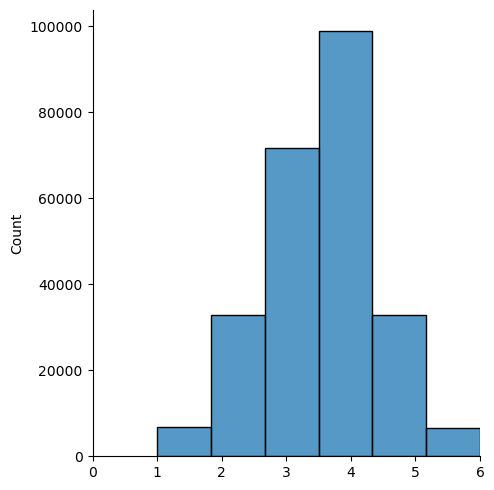

```python
# With 4 samples, plot lookslike Normal Distribution.
sns.displot(x=mean4, bins=6)
plt.xlim(0,6)
```

```python
# Sample mean is equal to original mean
np.mean(mean4)
```

```
3.497105
```

```python
# S.D. is equal to half of original S.D.
np.std(mean4)
```

```
0.8534051610899713
```

```python
# With 100 samples;
mean100 = one_m.reshape(10000,100).mean(axis=1)
```

```
(0.0, 6.0)
```

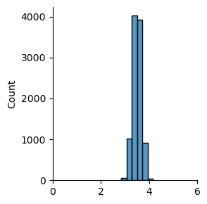

```python
sns.displot(x=mean100, bins=6, height = 3)
plt.xlim(0,6)
```

```python
# With 100 samples, mean is same as Original
np.mean(mean100)
```

```
3.4971049999999995
```

```python
np.std(mean100)
```

```
0.17140498526880715
```

#### Exercise:

```
 Take samples from that, take 4 samples, take the average of that, make a histogram,
 Take one 100 samples from that, make a histogram of that.
```

```python
a = np.random.normal(100,5,1000)
b = np.random.normal(80,5,1000)
```

```python
bm_data = np.append(a, b)
np.random.shuffle(bm_data)
```

```
(60.0, 120.0)
```

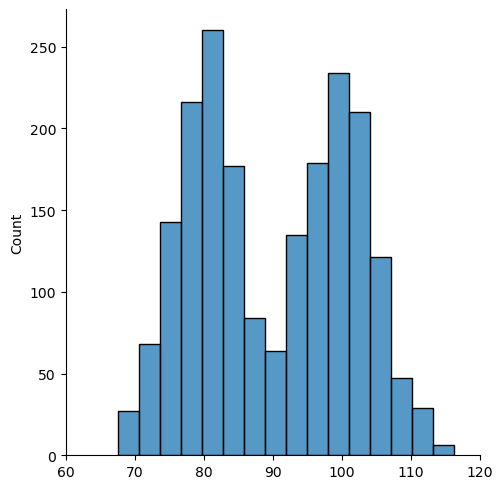

```python
# Bomodal Distribution
sns.displot(bm_data)
plt.xlim(60,120)
```

```
(60.0, 120.0)
```

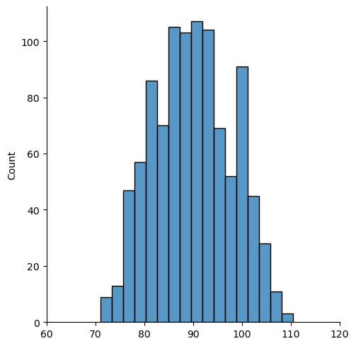

```python
bm_2 = bm_data.reshape(1000, 2).mean(axis=1)
sns.displot(bm_2)
plt.xlim(60,120)
```

```
(60.0, 120.0)
```

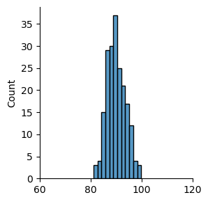

```python
bm_10 = bm_data.reshape(200, 10).mean(axis=1)
sns.displot(bm_10,height =3)
plt.xlim(60,120)
```

#### Hypothesis Testing Using Python

A machine is producing perfume bottles with the long term average of 150cc and the standard deviation of 2 cc. Four bottles were picked and the average volume was found to be 153.8cc. Has the average volume changed from 150cc? Test with 95% confidence level.

Alternate Hypothesis: Mean volume != 150cc

Null Hypothesis: Mean volume = 150cc

Alpha = 1 - 0.95 = 0.05

Z calculated = (Observed mean - population mean) / standard error z = (x — μ) / (σ / √n)

```python
# Since this is a two tail test and Alpha is 0.05, so we will be looking at 2.5 percent area in the left and the right tail.
```

```python
import numpy as np
import pandas as pd
import matplotlib.pyplot as plt
import seaborn as sns
from scipy.stats import norm
```

```python
#Z calculated = (Observed mean - population mean) / standard error z = (x — μ) / (σ / √n)
z_cal =  (153.8 - 150) / (2 / np.sqrt(4))
z_cal
```

```
3.8000000000000114
```

```python
# Finding out the critical values of Z.
```

```python
# norm.pdf(x, loc=0, scale=1) Probability density function.

# norm.cdf(x, loc=0, scale=1)  Cumulative distribution function. (area to the left of x)

# norm.sf(x, loc=0, scale=1) Survival function (also defined as 1 - cdf, but sf is sometimes more accurate).

# norm.ppf(q, loc=0, scale=1) Percent point function (inverse of cdf — percentiles).

# norm.isf(q, loc=0, scale=1) Inverse survival function (inverse of sf).
```

let's consider a normal distribution, which has the average of zero and the standard deviation of one, and that is the default here as well for all these cases,

location is equal to zero means the mean is equal to zero and scale is equal to one means the standard deviation is one. So, if that is the case, then I just need to give the value of X.

This is generally used when you actually want to make a normal distribution plot.

```python
 norm.pdf(0)
```

```
0.3989422804014327
```

```python
#Left side
norm.cdf(-1.96)    # 2.5%
```

```
0.024997895148220435
```

```python
# Opposite function of cdf is ppf
norm.ppf(0.025)    # Area = 0.025 and z= 1.96
```

```
-1.9599639845400545
```

```python
# Area to the right
norm.sf(1.96)        # z= 1.96 and Area = 0.025
```

```
0.024997895148220435
```

```python
# Oppsite to sf is isf
norm.isf(0.025)    # Area = 0.025 and z= 1.96
```

```
1.9599639845400545
```

So now, the conclusion of this is we have 2 Z values, which gives us area on the left, and area on the right as 2.5 percent.

And these values are 1.96, which you can see here and which you can see here. So, these are the two critical values of Z value.

Now, if these are the two critical values and our calculated value is 3.8, which is far far right, that means we reject the null hypothesis because Z calculated is falling in the rejection zone.

```python
p_Value = 2 * norm.sf(z_cal)
```

```python
p_Value   #This P value is less than Alpha, which is 0.05. So with this, we reject this null hypothesis.
          #So, remember that when P is low, null must go.
```

```
0.0001446960878502333
```

### Exercise

10% Area on the Right Tail At what value of z the area on the right tail of a Normal distribution will be 10%? Assign the answer to the variable answer.

```python
# The following line has been placed for your convenience
from scipy.stats import norm

#############################
# Enter your solution below #
#############################
answer = norm.isf(0.10)
answer
```

```
1.2815515655446004
```

```python
answer = norm.ppf(.9)
answer
```

```
1.2815515655446004
```